# Coursera Data Science Capstone - Milestone Report

E. Manton

February 16, 2018

### Introduction

The **Coursera Data Science Capstone - Milestone Report** (aka, **“the report”**) is intended to give an introductory look at analyzing the SwiftKey data set and figuring out:

1. What the data consists of, and
2. Identifying the standard tools and models used for this type of data.

The report is then to be written in a clear, concise, style that a data scientist *OR* non-data scientist can understand and make sense of.

### Purpose

The purpose of the report is a four-fold **exploratory data analysis** that will:

1. Demonstrate that the data has been downloaded from Swiftkey (via Coursera) and successfully loaded it in to R.
2. Create a basic report of summary statistics about the data sets to include:
- Word counts, line counts and basic data tables,
- Basic plots, such as histograms and pie charts, to illustrate features of the data.
3. Report any interesting findings about the data so far amassed.
4. Present the basic plan behind creating a prediction algorithm and Shiny app from the data.

### Load Data, Calculate Size, Word Count, and Summarize

The Swiftkey data consists of four datasets, each in a different language (one each in German, English, Russian, and Finnish), containing random:

1. blog entries
2. news entries
3. twitter feeds

For this report, we will process the **English data**, and reference the German, Finnish, and Russian sets to possibly match foreign language characters and/or words embedded in the English data.

#### **Download the data** and unzip on Windows 10 PC

```r
PkZip extract all...
```

#### **Read the data into R** from the connection (simple text files)

```r
blog_entries<-readLines("C:/Users/Mommy/OneDrive/Coursera/Data Science Specialization/Capstone/Data/final/en_US/en_US.blogs.txt", skipNul = TRUE, warn= FALSE)
news_entries<-readLines("C:/Users/Mommy/OneDrive/Coursera/Data Science Specialization/Capstone/Data/final/en_US/en_US.news.txt", skipNul = TRUE, warn=FALSE)
twitter_feeds<-readLines("C:/Users/Mommy/OneDrive/Coursera/Data Science Specialization/Capstone/Data/final/en_US/en_US.twitter.txt", skipNul = TRUE, warn=FALSE)
```

#### Calculate the **SIZE** of the English dataset (in megabytes) and display

```r
blog_entries_size<-file.info("C:/Users/Mommy/OneDrive/Coursera/Data Science Specialization/Capstone/Data/final/en_US/en_US.blogs.txt")$size/ 1024 ^ 2
news_entries_size<-file.info("C:/Users/Mommy/OneDrive/Coursera/Data Science Specialization/Capstone/Data/final/en_US/en_US.news.txt")$size/ 1024 ^ 2
twitter_feeds_size<-file.info("C:/Users/Mommy/OneDrive/Coursera/Data Science Specialization/Capstone/Data/final/en_US/en_US.twitter.txt")$size/ 1024 ^ 2
```

```r
eng_data_set_size<-c(blog_entries_size,news_entries_size,twitter_feeds_size)
data_frame_size<-data.frame(eng_data_set_size)
names(data_frame_size)[1] <-"MBs"
row.names(data_frame_size) <- c("Blog entries", "News entries", "Twitter Feeds")
data_frame_size
```

```
##                    MBs
## Blog entries  200.4242
## News entries  196.2775
## Twitter Feeds 159.3641
```

#### Calculate the **LINE COUNT** of the English dataset and display

```r
blog_entries_line_count<-length(blog_entries)
news_entries_line_count<-length(news_entries)
twitter_feeds_line_count<-length(twitter_feeds)

data_set_length <-c(blog_entries_line_count,news_entries_line_count, twitter_feeds_line_count)
eng_data_frame_line_count <-data.frame(data_set_length)
names(eng_data_frame_line_count)[1] <-"Line Count"
row.names(eng_data_frame_line_count) <- c("Blog entries", "News entries", "Twitter Feeds")
eng_data_frame_line_count
```

```
##               Line Count
## Blog entries      899288
## News entries       77259
## Twitter Feeds    2360148
```

#### Calculate the **WORD COUNT** of the English dataset and display

```r
library(ngram)
blog_entries_word_count <-wordcount(blog_entries)
news_entries_word_count <-wordcount(news_entries)
twitter_feeds_word_count <-wordcount(twitter_feeds)

data_set_word_count <-c(blog_entries_word_count, news_entries_word_count, twitter_feeds_word_count)
eng_data_frame_word_count <-data.frame(data_set_word_count)
names(eng_data_frame_word_count)[1] <-"Word Count"
row.names(eng_data_frame_word_count) <- c("Blog entries", "News entries", "Twitter Feeds")
eng_data_frame_word_count
```

```
##               Word Count
## Blog entries    37334131
## News entries     2643969
## Twitter Feeds   30373583
```

#### **SUMMERIZE** the English dataset and display two sample entries from each file

```r
summary(blog_entries)
```

```
##    Length     Class      Mode
##    899288 character character
```

```r
head(blog_entries,2)
```

```
## [1] "In the years thereafter, most of the Oil fields and platforms were named after pagan âgodsâ."
## [2] "We love you Mr. Brown."
```

```r
summary(news_entries)
```

```
##    Length     Class      Mode
##     77259 character character
```

```r
head(news_entries,2)
```

```
## [1] "He wasn't home alone, apparently."
## [2] "The St. Louis plant had to close. It would die of old age. Workers had been making cars there since the onset of mass automotive production in the 1920s."
```

```r
summary(twitter_feeds)
```

```
##    Length     Class      Mode
##   2360148 character character
```

```r
head(twitter_feeds,2)
```

```
## [1] "How are you? Btw thanks for the RT. You gonna be in DC anytime soon? Love to see you. Been way, way too long."
## [2] "When you meet someone special... you'll know. Your heart will beat more rapidly and you'll smile for no reason."
```

### Basic Plots

#### Reduced Sample Size - training sets

We will use **1/100th** of each data file for our reduced sample size, and create the necessary data subsets from them.

```r
sample_size <- 0.01
blogs_index <- sample(seq_len(blog_entries_line_count),blog_entries_line_count*sample_size)
news_index <- sample(seq_len(length(news_entries)),length(news_entries)*sample_size)
twitter_index <- sample(seq_len(length(twitter_feeds)),length(twitter_feeds)*sample_size)

blogs_sub <- blog_entries[blogs_index[]]
news_sub <- news_entries[news_index[]]
twitter_sub <- twitter_feeds[twitter_index[]]
```

#### Combine the Subsets - final training set

We will now create a corpus from the data subsets. The **tm** Library will assist us in this task. The process involves removing all non-ASCII character data, punctuation marks, excess white space, numeric data, converting the remaining alpha characters to lower case, and generating the entire corpus in plain text. A brief summary of the corpus is provided.

```r
library(tm)
korpus <- Corpus(VectorSource(c(blogs_sub, news_sub, twitter_sub)),readerControl=list(reader=readPlain,language="en"))
korpus <- Corpus(VectorSource(sapply(korpus, function(row) iconv(row, "latin1", "ASCII", sub=""))))
korpus <- tm_map(korpus, removePunctuation)
korpus <- tm_map(korpus, stripWhitespace)
korpus <- tm_map(korpus, content_transformer(tolower))
korpus <- tm_map(korpus, removeNumbers)
korpus <- tm_map(korpus, PlainTextDocument)
korpus <- Corpus(VectorSource(korpus))
head(korpus,5)
```

```
## <<SimpleCorpus>>
## Metadata:  corpus specific: 1, document level (indexed): 0
## Content:  documents: 3
```

#### Display as a **HISTOGRAM**

We will now use our cleaned data subset to generate a histogram of the thirty most frequently used words in the corpus. The libraries **slam** and **ggplot2** will help with this task.

```r
library(slam)
```

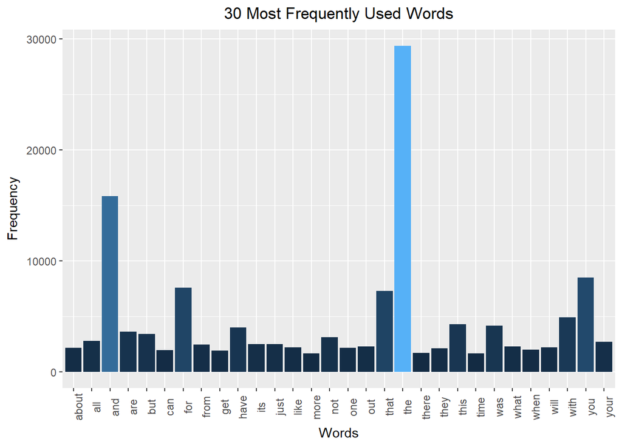

```r
library(ggplot2)
s_korpus <-TermDocumentMatrix(korpus,control=list(minWordLength=1))
wordFrequency <-rowapply_simple_triplet_matrix(s_korpus,sum)
wordFrequency <-wordFrequency[order(wordFrequency,decreasing=T)]
mostFrequent30 <-as.data.frame(wordFrequency[1:30])
mostFrequent30 <-data.frame(Words = row.names(mostFrequent30),mostFrequent30)
names(mostFrequent30)[2] = "Frequency"
row.names(mostFrequent30) <-NULL
mf30Plot = ggplot(data=mostFrequent30, aes(x=Words, y=Frequency, fill=Frequency)) + geom_bar(stat="identity") +  guides(fill=FALSE) + theme(axis.text.x=element_text(angle=90))
# mf30Plot +labs(title="30 Most Frequently Used Words")
mf30Plot + ggtitle("30 Most Frequently Used Words") + theme(plot.title = element_text(hjust = 0.5))
```

#### Display as a **PIE CHART**

We will now use our cleaned data subset to generate a pie chart of the five most frequently used words in the corpus. The library **plotrix** will help with this task.

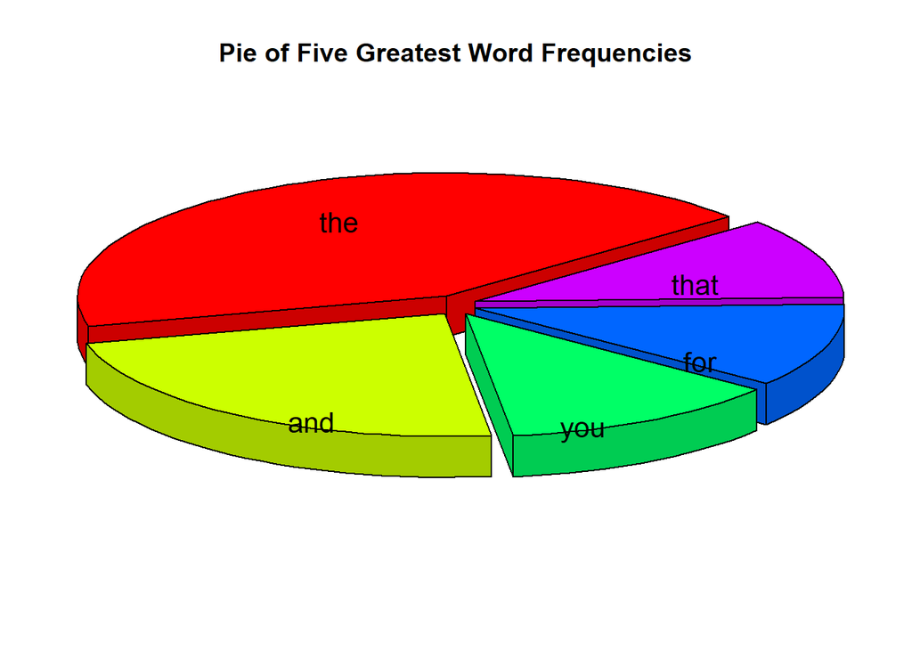

```r
library(plotrix)
mostFrequent10 <-head(mostFrequent30,5)
pie3D(mostFrequent10$Frequency, labels = mostFrequent10$Words, main = "Pie of Five Greatest Word Frequencies", explode=0.1, radius=1.8, labelcex = 1.3, start=0.7)
```

### Basic Project Plan

The basic plan is to use the initial data analysis presented herein to further progress with the prediction algorithm necessary for the Shiny application - a predictive model of English text. One way of doing this might be to investigate what is possible using Markov Chains. Further analysis will be done using NGram modeling, to predict next-word selection with accuracy. All will be incorporated into a user-friendly Shiny front end that will allow the user to interact with the data and make logical next-word selections.